# NavCity Performance Analysis: Low NARA Scorers (BNC01 & BNC037)

Analysis

2025-11-12

## Introduction

This analysis examines the NavCity performance of two young adult participants (BNC01 and BNC037) who scored below the NARA cutoff of 3.5, comparing them to the rest of the young adult cohort.

```r
library(tidyverse)
library(ggplot2)
library(knitr)
library(patchwork)
```

```r
# Load the data
ya_averaged <- read.csv("/Volumes/YB_Drive/NavAging_Paper/data/ya_averaged_results.csv")
ya_merged <- read.csv("/Volumes/YB_Drive/NavAging_Paper/data/ya_merged_results.csv")
non_nav <- read.csv("/Volumes/YB_Drive/NavAging_Paper/data/non_nav_data.csv")

# Check which participants are in YA group
ya_participants <- ya_averaged %>%
  pull(Participant) %>%
  unique()

# Get NARA scores for YA participants
nara_data <- non_nav %>%
  filter(Group == "YA") %>%
  select(Participant, NARA, Group, SBSOD, MiniCog)

# Identify low NARA scorers
low_nara <- c("BNC01", "BNC37")

# Add a grouping variable
ya_averaged <- ya_averaged %>%
  mutate(NARA_Group = case_when(
    Participant %in% low_nara ~ "Low NARA (< 3.5)",
    TRUE ~ "Normal NARA"
  ))

ya_merged <- ya_merged %>%
  mutate(NARA_Group = case_when(
    Participant %in% low_nara ~ "Low NARA (< 3.5)",
    TRUE ~ "Normal NARA"
  ))
```

## NARA Score Distribution

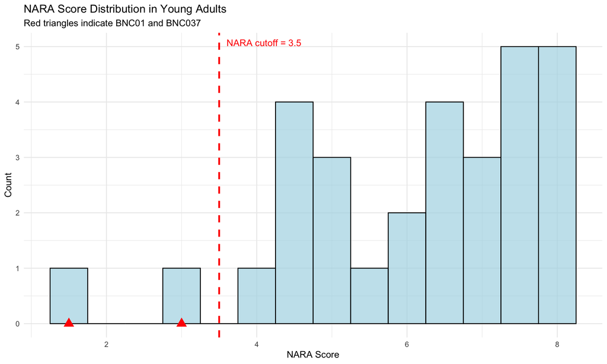

```r
ggplot(nara_data, aes(x = NARA)) +
  geom_histogram(binwidth = 0.5, fill = "lightblue", color = "black", alpha = 0.7) +
  geom_vline(xintercept = 3.5, color = "red", linetype = "dashed", size = 1) +
  geom_point(data = nara_data %>% filter(Participant %in% low_nara),
             aes(x = NARA, y = 0), color = "red", size = 4, shape = 17) +
  annotate("text", x = 3.5, y = Inf, label = "NARA cutoff = 3.5",
           hjust = -0.1, vjust = 2, color = "red") +
  labs(title = "NARA Score Distribution in Young Adults",
       subtitle = "Red triangles indicate BNC01 and BNC037",
       x = "NARA Score", y = "Count") +
  theme_minimal()
```

```r
# Show NARA scores for low scorers
kable(nara_data %>%
        filter(Participant %in% low_nara) %>%
        arrange(NARA),
      caption = "NARA Scores for Low Scorers")
```

NARA Scores for Low Scorers

| Participant | NARA | Group | SBSOD | MiniCog |
| --- | --- | --- | --- | --- |
| BNC37 | 1.5 | YA | 4.87 | 5 |
| BNC01 | 3.0 | YA | 2.20 | 5 |

## Summary Statistics

```r
# Calculate summary statistics by NARA group
summary_stats <- ya_averaged %>%
  group_by(NARA_Group) %>%
  summarise(
    N_Participants = n_distinct(Participant),
    Mean_Speed = mean(Speed, na.rm = TRUE),
    SD_Speed = sd(Speed, na.rm = TRUE),
    Mean_Distance = mean(Distance, na.rm = TRUE),
    SD_Distance = sd(Distance, na.rm = TRUE),
    Mean_Nav_Time = mean(Navigation_Time, na.rm = TRUE),
    SD_Nav_Time = sd(Navigation_Time, na.rm = TRUE),
    Mean_Dwell = mean(Mean_Dwell, na.rm = TRUE),
    SD_Dwell = sd(Mean_Dwell, na.rm = TRUE),
    Mean_Teleportations = mean(Teleportations, na.rm = TRUE),
    SD_Teleportations = sd(Teleportations, na.rm = TRUE)
  )

kable(summary_stats, digits = 2,
      caption = "Summary Statistics: Low NARA vs Normal NARA Young Adults")
```

Summary Statistics: Low NARA vs Normal NARA Young Adults

| NARA_Group | N_Participants | Mean_Speed | SD_Speed | Mean_Distance | SD_Distance | Mean_Nav_Time | SD_Nav_Time | Mean_Dwell | SD_Dwell | Mean_Teleportations | SD_Teleportations |
| --- | --- | --- | --- | --- | --- | --- | --- | --- | --- | --- | --- |
| Low NARA (< 3.5) | 2 | 10.48 | 2.07 | 312.59 | 80.01 | 33.95 | 14.29 | 0.92 | NA | 40.85 | 10.47 |
| Normal NARA | 28 | 14.05 | 5.62 | 250.69 | 110.33 | 28.66 | 21.73 | 0.89 | NA | 34.85 | 20.48 |

## Performance Comparisons: Overall Averages

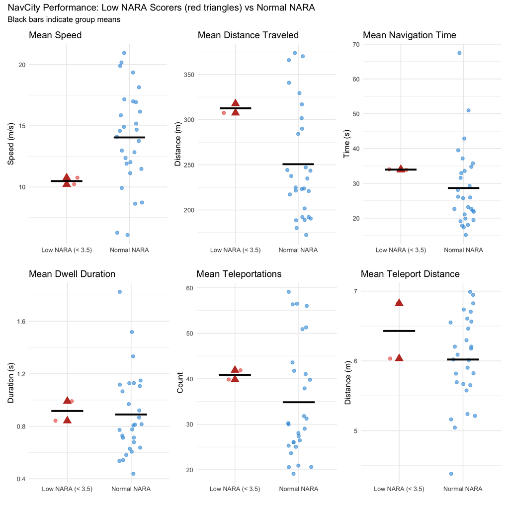

```r
# Calculate participant-level averages (across all blocks)
participant_avg <- ya_averaged %>%
  group_by(Participant, NARA_Group) %>%
  summarise(
    Speed = mean(Speed, na.rm = TRUE),
    Distance = mean(Distance, na.rm = TRUE),
    Navigation_Time = mean(Navigation_Time, na.rm = TRUE),
    Mean_Dwell = mean(Mean_Dwell, na.rm = TRUE),
    Teleportations = mean(Teleportations, na.rm = TRUE),
    Mean_Teleport_Distance = mean(Mean_Teleport_Distance, na.rm = TRUE)
  )

# Create color palette
colors <- c("Low NARA (< 3.5)" = "#e74c3c", "Normal NARA" = "#3498db")

# Speed
p1 <- ggplot(participant_avg, aes(x = NARA_Group, y = Speed, color = NARA_Group)) +
  geom_jitter(width = 0.2, size = 2, alpha = 0.6) +
  geom_point(data = participant_avg %>% filter(Participant %in% low_nara),
             aes(x = NARA_Group, y = Speed),
             color = "#c0392b", size = 4, shape = 17) +
  stat_summary(fun = mean, geom = "crossbar", width = 0.5, color = "black") +
  scale_color_manual(values = colors) +
  labs(title = "Mean Speed", x = "", y = "Speed (m/s)") +
  theme_minimal() +
  theme(legend.position = "none")

# Distance
p2 <- ggplot(participant_avg, aes(x = NARA_Group, y = Distance, color = NARA_Group)) +
  geom_jitter(width = 0.2, size = 2, alpha = 0.6) +
  geom_point(data = participant_avg %>% filter(Participant %in% low_nara),
             aes(x = NARA_Group, y = Distance),
             color = "#c0392b", size = 4, shape = 17) +
  stat_summary(fun = mean, geom = "crossbar", width = 0.5, color = "black") +
  scale_color_manual(values = colors) +
  labs(title = "Mean Distance Traveled", x = "", y = "Distance (m)") +
  theme_minimal() +
  theme(legend.position = "none")

# Navigation Time
p3 <- ggplot(participant_avg, aes(x = NARA_Group, y = Navigation_Time, color = NARA_Group)) +
  geom_jitter(width = 0.2, size = 2, alpha = 0.6) +
  geom_point(data = participant_avg %>% filter(Participant %in% low_nara),
             aes(x = NARA_Group, y = Navigation_Time),
             color = "#c0392b", size = 4, shape = 17) +
  stat_summary(fun = mean, geom = "crossbar", width = 0.5, color = "black") +
  scale_color_manual(values = colors) +
  labs(title = "Mean Navigation Time", x = "", y = "Time (s)") +
  theme_minimal() +
  theme(legend.position = "none")

# Dwell Duration
p4 <- ggplot(participant_avg, aes(x = NARA_Group, y = Mean_Dwell, color = NARA_Group)) +
  geom_jitter(width = 0.2, size = 2, alpha = 0.6) +
  geom_point(data = participant_avg %>% filter(Participant %in% low_nara),
             aes(x = NARA_Group, y = Mean_Dwell),
             color = "#c0392b", size = 4, shape = 17) +
  stat_summary(fun = mean, geom = "crossbar", width = 0.5, color = "black") +
  scale_color_manual(values = colors) +
  labs(title = "Mean Dwell Duration", x = "", y = "Duration (s)") +
  theme_minimal() +
  theme(legend.position = "none")

# Teleportations
p5 <- ggplot(participant_avg, aes(x = NARA_Group, y = Teleportations, color = NARA_Group)) +
  geom_jitter(width = 0.2, size = 2, alpha = 0.6) +
  geom_point(data = participant_avg %>% filter(Participant %in% low_nara),
             aes(x = NARA_Group, y = Teleportations),
             color = "#c0392b", size = 4, shape = 17) +
  stat_summary(fun = mean, geom = "crossbar", width = 0.5, color = "black") +
  scale_color_manual(values = colors) +
  labs(title = "Mean Teleportations", x = "", y = "Count") +
  theme_minimal() +
  theme(legend.position = "none")

# Teleport Distance
p6 <- ggplot(participant_avg, aes(x = NARA_Group, y = Mean_Teleport_Distance, color = NARA_Group)) +
  geom_jitter(width = 0.2, size = 2, alpha = 0.6) +
  geom_point(data = participant_avg %>% filter(Participant %in% low_nara),
             aes(x = NARA_Group, y = Mean_Teleport_Distance),
             color = "#c0392b", size = 4, shape = 17) +
  stat_summary(fun = mean, geom = "crossbar", width = 0.5, color = "black") +
  scale_color_manual(values = colors) +
  labs(title = "Mean Teleport Distance", x = "", y = "Distance (m)") +
  theme_minimal() +
  theme(legend.position = "none")

# Combine plots
(p1 + p2 + p3) / (p4 + p5 + p6) +
  plot_annotation(
    title = "NavCity Performance: Low NARA Scorers (red triangles) vs Normal NARA",
    subtitle = "Black bars indicate group means"
  )
```

## Performance Across Blocks

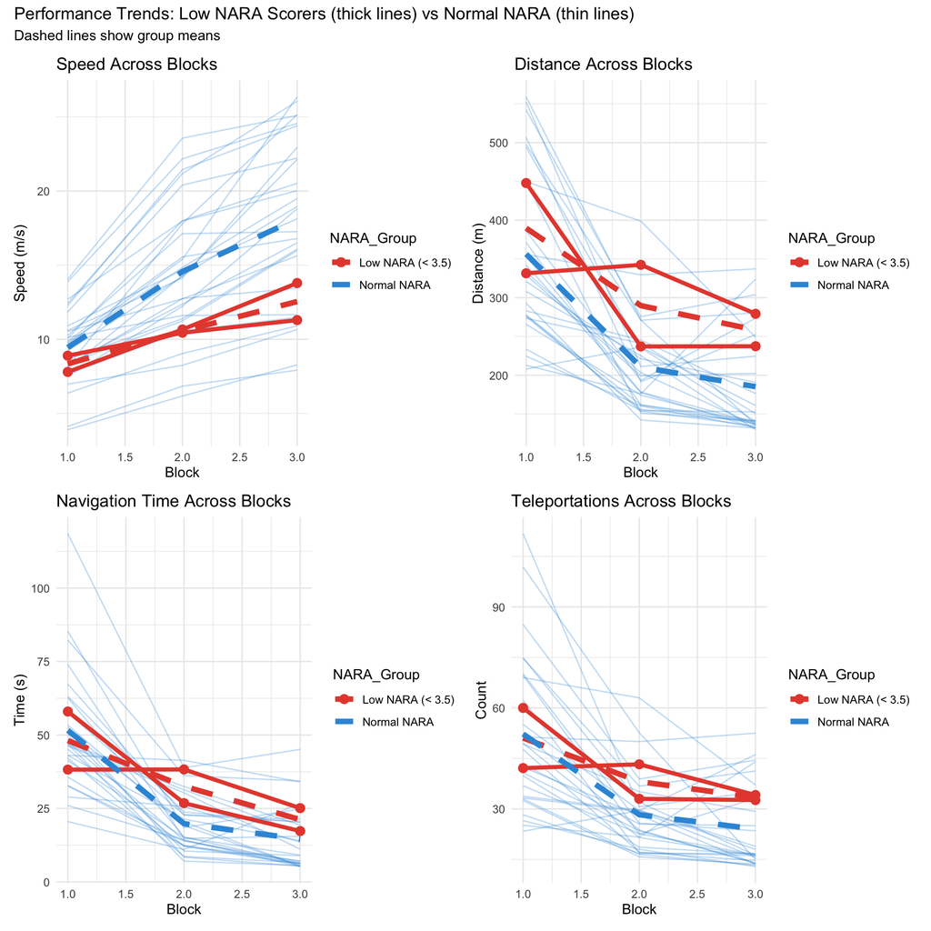

```r
# Speed by block
b1 <- ggplot(ya_averaged, aes(x = Block_Num, y = Speed, group = Participant)) +
  geom_line(aes(color = NARA_Group), alpha = 0.3) +
  geom_line(data = ya_averaged %>% filter(Participant %in% low_nara),
            aes(color = NARA_Group), size = 1.5) +
  geom_point(data = ya_averaged %>% filter(Participant %in% low_nara),
             aes(color = NARA_Group), size = 3) +
  stat_summary(aes(group = NARA_Group, color = NARA_Group),
               fun = mean, geom = "line", size = 2, linetype = "dashed") +
  scale_color_manual(values = colors) +
  labs(title = "Speed Across Blocks", x = "Block", y = "Speed (m/s)") +
  theme_minimal()

# Distance by block
b2 <- ggplot(ya_averaged, aes(x = Block_Num, y = Distance, group = Participant)) +
  geom_line(aes(color = NARA_Group), alpha = 0.3) +
  geom_line(data = ya_averaged %>% filter(Participant %in% low_nara),
            aes(color = NARA_Group), size = 1.5) +
  geom_point(data = ya_averaged %>% filter(Participant %in% low_nara),
             aes(color = NARA_Group), size = 3) +
  stat_summary(aes(group = NARA_Group, color = NARA_Group),
               fun = mean, geom = "line", size = 2, linetype = "dashed") +
  scale_color_manual(values = colors) +
  labs(title = "Distance Across Blocks", x = "Block", y = "Distance (m)") +
  theme_minimal()

# Navigation Time by block
b3 <- ggplot(ya_averaged, aes(x = Block_Num, y = Navigation_Time, group = Participant)) +
  geom_line(aes(color = NARA_Group), alpha = 0.3) +
  geom_line(data = ya_averaged %>% filter(Participant %in% low_nara),
            aes(color = NARA_Group), size = 1.5) +
  geom_point(data = ya_averaged %>% filter(Participant %in% low_nara),
             aes(color = NARA_Group), size = 3) +
  stat_summary(aes(group = NARA_Group, color = NARA_Group),
               fun = mean, geom = "line", size = 2, linetype = "dashed") +
  scale_color_manual(values = colors) +
  labs(title = "Navigation Time Across Blocks", x = "Block", y = "Time (s)") +
  theme_minimal()

# Teleportations by block
b4 <- ggplot(ya_averaged, aes(x = Block_Num, y = Teleportations, group = Participant)) +
  geom_line(aes(color = NARA_Group), alpha = 0.3) +
  geom_line(data = ya_averaged %>% filter(Participant %in% low_nara),
            aes(color = NARA_Group), size = 1.5) +
  geom_point(data = ya_averaged %>% filter(Participant %in% low_nara),
             aes(color = NARA_Group), size = 3) +
  stat_summary(aes(group = NARA_Group, color = NARA_Group),
               fun = mean, geom = "line", size = 2, linetype = "dashed") +
  scale_color_manual(values = colors) +
  labs(title = "Teleportations Across Blocks", x = "Block", y = "Count") +
  theme_minimal()

(b1 + b2) / (b3 + b4) +
  plot_annotation(
    title = "Performance Trends: Low NARA Scorers (thick lines) vs Normal NARA (thin lines)",
    subtitle = "Dashed lines show group means"
  )
```

## Correlation with NARA Scores

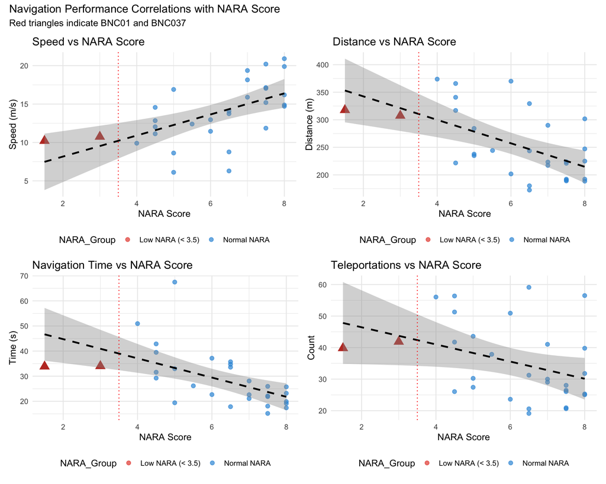

```r
# Merge NARA scores with navigation data
participant_avg_nara <- participant_avg %>%
  left_join(nara_data %>% select(Participant, NARA), by = "Participant")

# Speed vs NARA
c1 <- ggplot(participant_avg_nara, aes(x = NARA, y = Speed)) +
  geom_point(aes(color = NARA_Group), size = 2, alpha = 0.7) +
  geom_point(data = participant_avg_nara %>% filter(Participant %in% low_nara),
             size = 4, color = "#c0392b", shape = 17) +
  geom_smooth(method = "lm", se = TRUE, color = "black", linetype = "dashed") +
  geom_vline(xintercept = 3.5, color = "red", linetype = "dotted") +
  scale_color_manual(values = colors) +
  labs(title = "Speed vs NARA Score", x = "NARA Score", y = "Speed (m/s)") +
  theme_minimal() +
  theme(legend.position = "bottom")

# Distance vs NARA
c2 <- ggplot(participant_avg_nara, aes(x = NARA, y = Distance)) +
  geom_point(aes(color = NARA_Group), size = 2, alpha = 0.7) +
  geom_point(data = participant_avg_nara %>% filter(Participant %in% low_nara),
             size = 4, color = "#c0392b", shape = 17) +
  geom_smooth(method = "lm", se = TRUE, color = "black", linetype = "dashed") +
  geom_vline(xintercept = 3.5, color = "red", linetype = "dotted") +
  scale_color_manual(values = colors) +
  labs(title = "Distance vs NARA Score", x = "NARA Score", y = "Distance (m)") +
  theme_minimal() +
  theme(legend.position = "bottom")

# Navigation Time vs NARA
c3 <- ggplot(participant_avg_nara, aes(x = NARA, y = Navigation_Time)) +
  geom_point(aes(color = NARA_Group), size = 2, alpha = 0.7) +
  geom_point(data = participant_avg_nara %>% filter(Participant %in% low_nara),
             size = 4, color = "#c0392b", shape = 17) +
  geom_smooth(method = "lm", se = TRUE, color = "black", linetype = "dashed") +
  geom_vline(xintercept = 3.5, color = "red", linetype = "dotted") +
  scale_color_manual(values = colors) +
  labs(title = "Navigation Time vs NARA Score", x = "NARA Score", y = "Time (s)") +
  theme_minimal() +
  theme(legend.position = "bottom")

# Teleportations vs NARA
c4 <- ggplot(participant_avg_nara, aes(x = NARA, y = Teleportations)) +
  geom_point(aes(color = NARA_Group), size = 2, alpha = 0.7) +
  geom_point(data = participant_avg_nara %>% filter(Participant %in% low_nara),
             size = 4, color = "#c0392b", shape = 17) +
  geom_smooth(method = "lm", se = TRUE, color = "black", linetype = "dashed") +
  geom_vline(xintercept = 3.5, color = "red", linetype = "dotted") +
  scale_color_manual(values = colors) +
  labs(title = "Teleportations vs NARA Score", x = "NARA Score", y = "Count") +
  theme_minimal() +
  theme(legend.position = "bottom")

(c1 + c2) / (c3 + c4) +
  plot_annotation(
    title = "Navigation Performance Correlations with NARA Score",
    subtitle = "Red triangles indicate BNC01 and BNC037"
  )
```

```r
# Calculate correlations
cor_results <- data.frame(
  Metric = c("Speed", "Distance", "Navigation_Time", "Teleportations"),
  Correlation = c(
    cor(participant_avg_nara$NARA, participant_avg_nara$Speed, use = "complete.obs"),
    cor(participant_avg_nara$NARA, participant_avg_nara$Distance, use = "complete.obs"),
    cor(participant_avg_nara$NARA, participant_avg_nara$Navigation_Time, use = "complete.obs"),
    cor(participant_avg_nara$NARA, participant_avg_nara$Teleportations, use = "complete.obs")
  )
)

# Add p-values
cor_results$P_Value <- c(
  cor.test(participant_avg_nara$NARA, participant_avg_nara$Speed)$p.value,
  cor.test(participant_avg_nara$NARA, participant_avg_nara$Distance)$p.value,
  cor.test(participant_avg_nara$NARA, participant_avg_nara$Navigation_Time)$p.value,
  cor.test(participant_avg_nara$NARA, participant_avg_nara$Teleportations)$p.value
)

kable(cor_results, digits = 3,
      caption = "Correlations between NARA Score and Navigation Metrics")
```

Correlations between NARA Score and Navigation Metrics

| Metric | Correlation | P_Value |
| --- | --- | --- |
| Speed | 0.578 | 0.001 |
| Distance | -0.573 | 0.001 |
| Navigation_Time | -0.568 | 0.001 |
| Teleportations | -0.370 | 0.044 |

## Statistical Comparisons

```r
# T-tests comparing low NARA vs normal NARA
metrics <- c("Speed", "Distance", "Navigation_Time", "Mean_Dwell", "Teleportations")

test_results <- data.frame()

for (metric in metrics) {
  low_nara_vals <- participant_avg %>%
    filter(NARA_Group == "Low NARA (< 3.5)") %>%
    pull(metric)

  normal_nara_vals <- participant_avg %>%
    filter(NARA_Group == "Normal NARA") %>%
    pull(metric)

  t_test <- t.test(low_nara_vals, normal_nara_vals)

  test_results <- rbind(test_results, data.frame(
    Metric = metric,
    Low_NARA_Mean = mean(low_nara_vals, na.rm = TRUE),
    Normal_NARA_Mean = mean(normal_nara_vals, na.rm = TRUE),
    Difference = mean(low_nara_vals, na.rm = TRUE) - mean(normal_nara_vals, na.rm = TRUE),
    T_Statistic = t_test$statistic,
    P_Value = t_test$p.value,
    Cohen_d = (mean(low_nara_vals, na.rm = TRUE) - mean(normal_nara_vals, na.rm = TRUE)) /
              sqrt((var(low_nara_vals, na.rm = TRUE) + var(normal_nara_vals, na.rm = TRUE)) / 2)
  ))
}

kable(test_results, digits = 3,
      caption = "Statistical Comparisons: Low NARA vs Normal NARA")
```

Statistical Comparisons: Low NARA vs Normal NARA

|  | Metric | Low_NARA_Mean | Normal_NARA_Mean | Difference | T_Statistic | P_Value | Cohen_d |
| --- | --- | --- | --- | --- | --- | --- | --- |
| t | Speed | 10.480 | 14.047 | -3.566 | -4.458 | 0.000 | -1.260 |
| t1 | Distance | 312.587 | 250.693 | 61.894 | 4.840 | 0.000 | 1.402 |
| t2 | Navigation_Time | 33.954 | 28.656 | 5.299 | 2.428 | 0.022 | 0.649 |
| t3 | Mean_Dwell | 0.916 | 0.890 | 0.027 | 0.279 | 0.800 | 0.113 |
| t4 | Teleportations | 40.854 | 34.851 | 6.003 | 2.318 | 0.031 | 0.670 |

## Outlier Detection

### Method 1: IQR Method (Tukey’s Fences)

```r
# Function to detect outliers using IQR method
detect_iqr_outliers <- function(x) {
  q1 <- quantile(x, 0.25, na.rm = TRUE)
  q3 <- quantile(x, 0.75, na.rm = TRUE)
  iqr <- q3 - q1
  lower_fence <- q1 - 1.5 * iqr
  upper_fence <- q3 + 1.5 * iqr
  x < lower_fence | x > upper_fence
}

# Detect outliers for each metric
metrics_to_check <- c("Speed", "Distance", "Navigation_Time", "Mean_Dwell",
                      "Teleportations", "Mean_Teleport_Distance")

iqr_outliers <- participant_avg %>%
  select(Participant, NARA_Group, all_of(metrics_to_check)) %>%
  pivot_longer(cols = all_of(metrics_to_check),
               names_to = "Metric",
               values_to = "Value") %>%
  group_by(Metric) %>%
  mutate(
    Q1 = quantile(Value, 0.25, na.rm = TRUE),
    Q3 = quantile(Value, 0.75, na.rm = TRUE),
    IQR = Q3 - Q1,
    Lower_Fence = Q1 - 1.5 * IQR,
    Upper_Fence = Q3 + 1.5 * IQR,
    Is_Outlier = Value < Lower_Fence | Value > Upper_Fence,
    Outlier_Type = case_when(
      Value < Lower_Fence ~ "Low",
      Value > Upper_Fence ~ "High",
      TRUE ~ "Normal"
    )
  ) %>%
  ungroup()

# Summary of outliers for BNC01 and BNC037
low_nara_iqr <- iqr_outliers %>%
  filter(Participant %in% low_nara) %>%
  select(Participant, Metric, Value, Q1, Q3, Lower_Fence, Upper_Fence,
         Is_Outlier, Outlier_Type)

kable(low_nara_iqr, digits = 2,
      caption = "IQR-Based Outlier Detection for BNC01 and BNC037")
```

IQR-Based Outlier Detection for BNC01 and BNC037

| Participant | Metric | Value | Q1 | Q3 | Lower_Fence | Upper_Fence | Is_Outlier | Outlier_Type |
| --- | --- | --- | --- | --- | --- | --- | --- | --- |
| BNC01 | Speed | 10.75 | 11.21 | 16.73 | 2.94 | 25.00 | FALSE | Normal |
| BNC01 | Distance | 307.46 | 205.60 | 306.03 | 54.95 | 456.68 | FALSE | Normal |
| BNC01 | Navigation_Time | 34.04 | 21.29 | 34.00 | 2.23 | 53.06 | FALSE | Normal |
| BNC01 | Mean_Dwell | 0.84 | 0.69 | 1.10 | 0.07 | 1.71 | FALSE | Normal |
| BNC01 | Teleportations | 41.88 | 26.04 | 41.84 | 2.34 | 65.55 | FALSE | Normal |
| BNC01 | Mean_Teleport_Distance | 6.03 | 5.68 | 6.56 | 4.35 | 7.89 | FALSE | Normal |
| BNC37 | Speed | 10.21 | 11.21 | 16.73 | 2.94 | 25.00 | FALSE | Normal |
| BNC37 | Distance | 317.71 | 205.60 | 306.03 | 54.95 | 456.68 | FALSE | Normal |
| BNC37 | Navigation_Time | 33.87 | 21.29 | 34.00 | 2.23 | 53.06 | FALSE | Normal |
| BNC37 | Mean_Dwell | 0.99 | 0.69 | 1.10 | 0.07 | 1.71 | FALSE | Normal |
| BNC37 | Teleportations | 39.83 | 26.04 | 41.84 | 2.34 | 65.55 | FALSE | Normal |
| BNC37 | Mean_Teleport_Distance | 6.82 | 5.68 | 6.56 | 4.35 | 7.89 | FALSE | Normal |

```r
# Count outliers by participant
outlier_counts <- iqr_outliers %>%
  filter(Is_Outlier) %>%
  count(Participant, name = "N_Outlier_Metrics") %>%
  arrange(desc(N_Outlier_Metrics))

kable(head(outlier_counts, 10),
      caption = "Participants with Most Outlier Metrics (IQR Method)")
```

Participants with Most Outlier Metrics (IQR Method)

| Participant | N_Outlier_Metrics |
| --- | --- |
| BNC09 | 1 |
| BNC35 | 1 |

### Method 2: Z-Score Method

```r
# Calculate z-scores
zscore_outliers <- participant_avg %>%
  select(Participant, NARA_Group, all_of(metrics_to_check)) %>%
  pivot_longer(cols = all_of(metrics_to_check),
               names_to = "Metric",
               values_to = "Value") %>%
  group_by(Metric) %>%
  mutate(
    Mean = mean(Value, na.rm = TRUE),
    SD = sd(Value, na.rm = TRUE),
    Z_Score = (Value - Mean) / SD,
    Is_Outlier_2SD = abs(Z_Score) > 2,
    Is_Outlier_3SD = abs(Z_Score) > 3
  ) %>%
  ungroup()

# Summary for BNC01 and BNC037
low_nara_zscore <- zscore_outliers %>%
  filter(Participant %in% low_nara) %>%
  select(Participant, Metric, Value, Z_Score, Is_Outlier_2SD, Is_Outlier_3SD)

kable(low_nara_zscore, digits = 2,
      caption = "Z-Score Based Outlier Detection for BNC01 and BNC037")
```

Z-Score Based Outlier Detection for BNC01 and BNC037

| Participant | Metric | Value | Z_Score | Is_Outlier_2SD | Is_Outlier_3SD |
| --- | --- | --- | --- | --- | --- |
| BNC01 | Speed | 10.75 | -0.77 | FALSE | FALSE |
| BNC01 | Distance | 307.46 | 0.85 | FALSE | FALSE |
| BNC01 | Navigation_Time | 34.04 | 0.45 | FALSE | FALSE |
| BNC01 | Mean_Dwell | 0.84 | -0.16 | FALSE | FALSE |
| BNC01 | Teleportations | 41.88 | 0.54 | FALSE | FALSE |
| BNC01 | Mean_Teleport_Distance | 6.03 | -0.02 | FALSE | FALSE |
| BNC37 | Speed | 10.21 | -0.91 | FALSE | FALSE |
| BNC37 | Distance | 317.71 | 1.02 | FALSE | FALSE |
| BNC37 | Navigation_Time | 33.87 | 0.43 | FALSE | FALSE |
| BNC37 | Mean_Dwell | 0.99 | 0.32 | FALSE | FALSE |
| BNC37 | Teleportations | 39.83 | 0.37 | FALSE | FALSE |
| BNC37 | Mean_Teleport_Distance | 6.82 | 1.23 | FALSE | FALSE |

```r
# Count outliers by participant (2 SD threshold)
zscore_counts <- zscore_outliers %>%
  filter(Is_Outlier_2SD) %>%
  count(Participant, name = "N_Outlier_Metrics_2SD") %>%
  arrange(desc(N_Outlier_Metrics_2SD))

kable(head(zscore_counts, 10),
      caption = "Participants with Most Outlier Metrics (Z-Score > 2)")
```

Participants with Most Outlier Metrics (Z-Score > 2)

| Participant | N_Outlier_Metrics_2SD |
| --- | --- |
| BNC09 | 2 |
| BNC35 | 1 |
| NAV055 | 1 |

### Method 3: Multivariate Outlier Detection (Mahalanobis Distance)

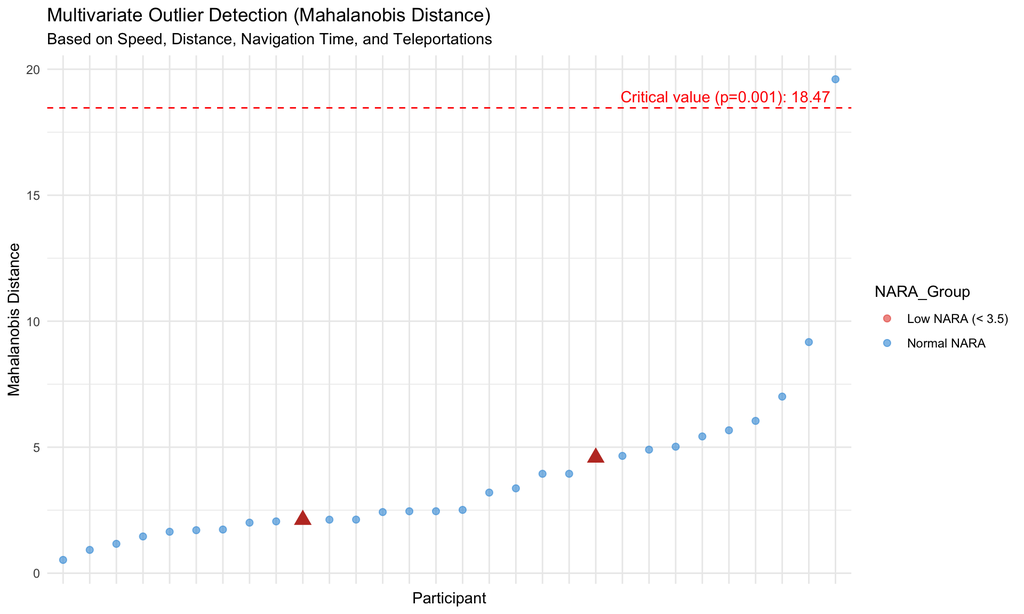

```r
# Calculate Mahalanobis distance
# First, create complete dataset with participant info
participant_avg_complete <- participant_avg %>%
  select(Participant, NARA_Group, Speed, Distance, Navigation_Time, Teleportations) %>%
  na.omit() %>%
  ungroup()  # This removes the grouping

# Extract only numeric columns for Mahalanobis calculation
nav_metrics <- participant_avg_complete %>%
  select(Speed, Distance, Navigation_Time, Teleportations)

# Calculate Mahalanobis distance
if (nrow(nav_metrics) > ncol(nav_metrics)) {
  mahal_dist <- mahalanobis(nav_metrics,
                             center = colMeans(nav_metrics),
                             cov = cov(nav_metrics))

  # Chi-square critical value (df = number of variables, p = 0.001)
  critical_value <- qchisq(0.999, df = ncol(nav_metrics))

  # Add Mahalanobis distance back to participant data
  participant_avg_complete <- participant_avg_complete %>%
    mutate(
      Mahalanobis_Distance = mahal_dist,
      Is_Multivariate_Outlier = mahal_dist > critical_value
    )

  # Show results for all participants
  mahal_results <- participant_avg_complete %>%
    arrange(desc(Mahalanobis_Distance)) %>%
    mutate(Rank = row_number())

  kable(head(mahal_results, 10), digits = 2,
        caption = "Top 10 Multivariate Outliers (Mahalanobis Distance)")

  # Highlight BNC01 and BNC037
  low_nara_mahal <- mahal_results %>%
    filter(Participant %in% low_nara)

  kable(low_nara_mahal, digits = 2,
        caption = "Mahalanobis Distance for BNC01 and BNC037")

  # Visualize
  ggplot(mahal_results, aes(x = reorder(Participant, Mahalanobis_Distance),
                            y = Mahalanobis_Distance)) +
    geom_point(aes(color = NARA_Group), size = 2, alpha = 0.6) +
    geom_point(data = low_nara_mahal,
               aes(x = Participant, y = Mahalanobis_Distance),
               color = "#c0392b", size = 4, shape = 17) +
    geom_hline(yintercept = critical_value, color = "red", linetype = "dashed") +
    annotate("text", x = Inf, y = critical_value,
             label = paste0("Critical value (p=0.001): ", round(critical_value, 2)),
             hjust = 1.1, vjust = -0.5, color = "red") +
    scale_color_manual(values = colors) +
    labs(title = "Multivariate Outlier Detection (Mahalanobis Distance)",
         subtitle = "Based on Speed, Distance, Navigation Time, and Teleportations",
         x = "Participant", y = "Mahalanobis Distance") +
    theme_minimal() +
    theme(axis.text.x = element_blank(),
          axis.ticks.x = element_blank())
}
```

### Outlier Detection Summary

```r
# Combine all outlier detection results
outlier_summary <- participant_avg %>%
  select(Participant, NARA_Group) %>%
  left_join(
    iqr_outliers %>%
      filter(Is_Outlier) %>%
      count(Participant, name = "N_IQR_Outliers"),
    by = "Participant"
  ) %>%
  left_join(
    zscore_outliers %>%
      filter(Is_Outlier_2SD) %>%
      count(Participant, name = "N_ZScore_Outliers"),
    by = "Participant"
  ) %>%
  left_join(
    participant_avg_complete %>%
      select(Participant, Mahalanobis_Distance, Is_Multivariate_Outlier),
    by = "Participant"
  ) %>%
  replace_na(list(N_IQR_Outliers = 0, N_ZScore_Outliers = 0,
                  Is_Multivariate_Outlier = FALSE)) %>%
  mutate(
    Total_Outlier_Flags = N_IQR_Outliers + N_ZScore_Outliers +
                          as.integer(Is_Multivariate_Outlier)
  ) %>%
  arrange(desc(Total_Outlier_Flags))

kable(head(outlier_summary, 10), digits = 2,
      caption = "Combined Outlier Detection Summary (Top 10)")
```

Combined Outlier Detection Summary (Top 10)

| Participant | NARA_Group | N_IQR_Outliers | N_ZScore_Outliers | Mahalanobis_Distance | Is_Multivariate_Outlier | Total_Outlier_Flags |
| --- | --- | --- | --- | --- | --- | --- |
| BNC09 | Normal NARA | 1 | 2 | 19.60 | TRUE | 4 |
| BNC35 | Normal NARA | 1 | 1 | 6.04 | FALSE | 2 |
| NAV055 | Normal NARA | 0 | 1 | 5.67 | FALSE | 1 |
| BNC01 | Low NARA (< 3.5) | 0 | 0 | 2.12 | FALSE | 0 |
| BNC02 | Normal NARA | 0 | 0 | 1.46 | FALSE | 0 |
| BNC03 | Normal NARA | 0 | 0 | 5.43 | FALSE | 0 |
| BNC04 | Normal NARA | 0 | 0 | 2.01 | FALSE | 0 |
| BNC05 | Normal NARA | 0 | 0 | 3.37 | FALSE | 0 |
| BNC07 | Normal NARA | 0 | 0 | 2.46 | FALSE | 0 |
| BNC08 | Normal NARA | 0 | 0 | 5.02 | FALSE | 0 |

```r
# Highlight BNC01 and BNC037
low_nara_summary <- outlier_summary %>%
  filter(Participant %in% low_nara)

kable(low_nara_summary, digits = 2,
      caption = "Combined Outlier Summary for BNC01 and BNC037")
```

Combined Outlier Summary for BNC01 and BNC037

| Participant | NARA_Group | N_IQR_Outliers | N_ZScore_Outliers | Mahalanobis_Distance | Is_Multivariate_Outlier | Total_Outlier_Flags |
| --- | --- | --- | --- | --- | --- | --- |
| BNC01 | Low NARA (< 3.5) | 0 | 0 | 2.12 | FALSE | 0 |
| BNC37 | Low NARA (< 3.5) | 0 | 0 | 4.59 | FALSE | 0 |

### Visualization: Outlier Status Across Metrics

[figure not shown]

```r
# Create a heatmap of outlier status
outlier_heatmap_data <- iqr_outliers %>%
  select(Participant, Metric, Is_Outlier, Outlier_Type) %>%
  mutate(
    Outlier_Value = case_when(
      Outlier_Type == "High" ~ 1,
      Outlier_Type == "Low" ~ -1,
      TRUE ~ 0
    )
  )

# Focus on participants with any outliers
participants_with_outliers <- outlier_heatmap_data %>%
  filter(Is_Outlier) %>%
  pull(Participant) %>%
  unique()

ggplot(outlier_heatmap_data %>% filter(Participant %in% participants_with_outliers),
       aes(x = Metric, y = Participant, fill = factor(Outlier_Value))) +
  geom_tile(color = "white", linewidth = 0.5) +
  geom_text(data = outlier_heatmap_data %>%
              filter(Participant %in% low_nara, Is_Outlier),
            aes(label = "★"), size = 6, color = "gold") +
  scale_fill_manual(values = c("-1" = "#3498db", "0" = "white", "1" = "#e74c3c"),
                    labels = c("Low Outlier", "Normal", "High Outlier"),
                    name = "Outlier Status") +
  labs(title = "Outlier Detection Heatmap (IQR Method)",
       subtitle = "Gold stars indicate BNC01 and BNC037",
       x = "Metric", y = "Participant") +
  theme_minimal() +
  theme(axis.text.x = element_text(angle = 45, hjust = 1))
```

## Individual Profiles

```r
# Detailed stats for BNC01 and BNC037
low_nara_details <- participant_avg %>%
  filter(Participant %in% low_nara) %>%
  left_join(nara_data, by = "Participant")

kable(low_nara_details, digits = 2,
      caption = "Detailed Profiles: BNC01 and BNC037")
```

Detailed Profiles: BNC01 and BNC037

| Participant | NARA_Group | Speed | Distance | Navigation_Time | Mean_Dwell | Teleportations | Mean_Teleport_Distance | NARA | Group | SBSOD | MiniCog |
| --- | --- | --- | --- | --- | --- | --- | --- | --- | --- | --- | --- |
| BNC01 | Low NARA (< 3.5) | 10.75 | 307.46 | 34.04 | 0.84 | 41.88 | 6.03 | 3.0 | YA | 2.20 | 5 |
| BNC37 | Low NARA (< 3.5) | 10.21 | 317.71 | 33.87 | 0.99 | 39.83 | 6.82 | 1.5 | YA | 4.87 | 5 |

```r
# Get percentile ranks for each metric
percentile_ranks <- participant_avg %>%
  filter(Participant %in% low_nara) %>%
  select(Participant, Speed, Distance, Navigation_Time, Teleportations) %>%
  pivot_longer(-Participant, names_to = "Metric", values_to = "Value") %>%
  left_join(
    participant_avg %>%
      select(Participant, Speed, Distance, Navigation_Time, Teleportations) %>%
      pivot_longer(-Participant, names_to = "Metric", values_to = "Value") %>%
      group_by(Metric) %>%
      summarise(Values = list(Value)),
    by = "Metric"
  ) %>%
  rowwise() %>%
  mutate(
    Percentile = sum(Value >= unlist(Values)) / length(unlist(Values)) * 100
  ) %>%
  select(Participant, Metric, Value, Percentile)

kable(percentile_ranks, digits = 2,
      caption = "Percentile Ranks for BNC01 and BNC037")
```

Percentile Ranks for BNC01 and BNC037

| Participant | Metric | Value | Percentile |
| --- | --- | --- | --- |
| BNC01 | Speed | 10.75 | 23.33 |
| BNC01 | Distance | 307.46 | 76.67 |
| BNC01 | Navigation_Time | 34.04 | 76.67 |
| BNC01 | Teleportations | 41.88 | 76.67 |
| BNC37 | Speed | 10.21 | 20.00 |
| BNC37 | Distance | 317.71 | 83.33 |
| BNC37 | Navigation_Time | 33.87 | 73.33 |
| BNC37 | Teleportations | 39.83 | 66.67 |

## Conclusion

### Key Findings:

1. **NARA Scores**: BNC01 and BNC037 scored below the 3.5 cutoff, making them the only two YAs below this threshold
2. **Outlier Detection**:
   - **IQR Method**: Identifies outliers using Tukey’s fences (Q1 - 1.5×IQR, Q3 + 1.5×IQR)
   - **Z-Score Method**: Flags values more than 2 standard deviations from the mean
   - **Mahalanobis Distance**: Detects multivariate outliers considering all metrics simultaneously
   - The summary table shows how many outlier flags each participant has across methods
3. **Performance Comparison**: The statistical tests show whether BNC01 and BNC037 perform significantly differently from the rest of the YA cohort on each metric
4. **Patterns**: The visualizations reveal whether low NARA scores correspond to specific navigation deficits

### Clinical Relevance:

Being a statistical outlier on navigation metrics while also having low NARA scores could indicate: - Navigation difficulties may be more pronounced in these individuals - Low NARA scores may be predictive of poor spatial navigation performance - These two participants might represent a subgroup worth investigating further